# STAT 687 - Chapter 7

Parametric Likelihood Fitting Concepts: Exponential Distribution

Maj Jason Freels

Air Force Institute of Technology

## This chapter explains

STAT 687 - Chapter 7

- Likelihood for a parametric model using discrete data
- Likelihood for samples containing right and left consored observations
- Use of parametric likelihood as a tool for data analysis and inference about a single population or process
- The use of likelihood and normal-approximation confidence intervals for model parameters and other quantities of interest
- The density approximation to the likelihood for observations reported as exact failures

# Section 7.1|Introduction

## $\S$ 7.1 - Introduction

STAT 687 - Chapter 7

The concepts presented in this chapter are used throughout the rest of the book

This chapter introduces basic ideas of parametric maximum likelihood estimation

- A very versitile method of fitting statistical models to data
- Can be applied to a wide variety of statistical models and data structures
- Provides optimal estimator under certain regularity conditions
  - Efficient - Estimates $\mathbf{\underline{\theta}}=\theta_{1},\theta_{2},...$ in the “best-manner”
  - Consistent - $\text{as}\;n\rightarrow\infty, \;\;f(\hat{\theta}_{_{MLE}}\xrightarrow{L}\theta)$

Example: $\bar{X}\xrightarrow{L}N(\mu,\sigma^{2}/n),\;\;\;n\rightarrow\infty$

## Example 7.1 - Time Between $\alpha$-Particle Emissions

STAT 687 - Chapter 7

Berkson investigated the time between $\alpha$-particle emissions from AM-241

The data are $10,220$ observed interarrival times (in units of $1/5000$ seconds)

- The times have been “binned” into intervals as shown in Table 7.1
- To illustrate the effect of sample size, random samples of the data were drawn
  - $n=20$
  - $n=200$
  - $n=2000$

Physics suggests that the interarrival times of $\alpha$ particles is $iid\; EXP(\theta)$

## Table 7.1 - Binned $\alpha$-particle data

STAT 687 - Chapter 7

$\begin{array}{cccccc} \hline Lower & Upper & n=10220 & n=2000 & n=200 & n=20 \\ \hline 0 & 100 & 1609 & 292 & 41 & 3 \\ 100 & 300 & 2424 & 494 & 44 & 7 \\ 300 & 500 & 1770 & 332 & 24 & 4 \\ 500 & 700 & 1306 & 236 & 32 & 1 \\ 700 & 1000 & 1213 & 261 & 29 & 3 \\ 1000 & 2000 & 1528 & 308 & 21 & 2 \\ 2000 & 4000 & 354 & 73 & 9 & 0 \\ 4000 & \infty & 16 & 4 & 0 & 0 \\ \hline \end{array}$

STAT 687 - Chapter 7

# Section 7.2|Parametric Likelihood

## Probability of the Data

STAT 687 - Chapter 7

$\mathcal{L}(\underline{\theta}|\underline{x})=f(\underline{x}|\underline{\theta})=\prod_{i=1}^{n}f(x_{i}|\underline{\theta}),\;\;\text{if}\;x_{i}\; iid$

$\mathcal{L}(\underline{\theta}|\underline{x})$

- Is a function of $\underline{\theta}$ assuming $\underline{x}=x_{1},...,x_{n}$ has already been observed
- What values of $\underline{\theta}$ are most likely to have produced $\underline{x}$?

$f(\underline{x}|\underline{\theta})$

- Is a function of $\underline{x}$ assuming $\underline{\theta}=\theta_{1},\theta_{2},...$ is known
- What data $\underline{x}$ are most likely to be produced by a distribution with parameters $\underline{\theta}$?

## Contributions to the Likelihood Function

STAT 687 - Chapter 7

Every unit under test contributes to the likelihood function (censored or failed)

$\mathcal{L}_{i}(\underline{\theta}|t_{i})=\begin{cases} S(t_{i}) &\mbox{for right censored observations}\\\\F(t_{i}) &\mbox{for left censored observations}\\\\F(t_{i})-F(t_{i-1}) &\mbox{for interval censored observations}\\\\\lim_{\Delta_i\rightarrow 0} \frac{(F(t_{i})-\Delta_{i})-F(t_{i})}{\Delta_{i}} &\mbox{for "exact" observations}\end{cases}$

## Properties of the Likelihood Function

STAT 687 - Chapter 7

1. $\mathcal{L}(\theta|\underline{x})\ge 0$
2. $\mathcal{L}(\theta|\underline{x})$ is not a pdf i.e. $\int \mathcal{L}(\theta|\underline{x}) \ne 1$
3. Suggests (relatively) which values of $\theta$ are more likely to have generated $\underline{x}$ (assuming the chosen parametric model is true)
4. If it exists, we say that the value of $\underline{\theta}$ that maximizes $\mathcal{L}(\underline{\theta}|\underline{x})$ is the maximum likelihood estimator (denoted $\hat{\theta}_{_{MLE}}$)
5. We often try to find $\theta_{_{MLE}}$ by maximizing the log-likelihood function $\mathcal{l}(\underline{\theta}|\underline{x})=\log\left[\mathcal{L}(\underline{\theta}|\underline{x})\right]$

## Properties of MLE’s

STAT 687 - Chapter 7

If certain regularity conditions are met

$\sqrt{n}\left(\hat{\theta}_{_{MLE}}-\theta\right)\xrightarrow{L}N\left(0,\mathscr{I}^{-1}_{\theta}\right)$

where the Fisher Information matrix evaluated at $\theta$ is

$\mathscr{I}_{\theta}=-E\left[\frac{\partial^2\mathcal{l}(\underline{\theta}|\underline{x})}{\partial\underline{\theta}(\partial\underline{\theta})^T}\right]=-E\left[\frac{\partial^2\mathcal{l}(\underline{\theta}|\underline{x})}{\partial\theta_i\partial\theta_j}\right]$  
Functions of MLE’s are also MLE’s and are asymptotocally normally distributed

- We use the Delta Method to find these asymptotic distributions

## ML Regularity Conditions

STAT 687 - Chapter 7

1. The support does not depend on $\theta$
2. Parameters are identifiable (i.e., for $\theta_1\ne\theta_2,\; f(t|\theta_1)\ne f(t|\theta_2), \;\forall t$)
3. The true value of $\theta$ is on the interior of the parameter space $\Theta$
4. $f(t|\theta)$ has a $3^{rd}$ mixed partial derivative
5. $E\left[\frac{\partial^{2}\log(f(t|\theta))}{\partial\theta(\partial\theta)^T}\right]=\frac{\partial^2 E\left[\log(f(t|\theta))\right]}{\partial\theta(\partial\theta)^T}$
6. Elements of $\mathscr{I}_{\theta}$ are finite and $\mathscr{I}_{\theta}$ is a positive-definite matrix

## $\S$ 7.2.2 - Likelihood Function and Its Maximum

STAT 687 - Chapter 7

From Eq 2.14, the total likelihood function may be expressed as

$\begin{aligned} \mathcal{L}(\underline{\theta}|\underline{x})&=C\prod_{i=1}^{n} \mathcal{L}_{i}(\underline{\theta}|x_i)\\ &=C\prod_{i=1}^{m+1}[F(t_{i})]^{l_{i}}[F(t_{i})-F(t_{i-1})]^{d_{i}}[1-F(t_{i})]^{r_{i}} \end{aligned}$

where $n = \sum_{j=1}^{m+1}(l_{j}+d_{j}+r_{j})$

## $\S$ 7.2.3 - Comparison of $\alpha$-Particle Data Analyses

STAT 687 - Chapter 7

In Example 7.3, the data are binned into $8$ intervals i.e. $m+1=8$

The total likelihoood is therefore

$\begin{aligned} \mathcal{L}(\underline{\theta}|\underline{x})&=C\prod_{j=1}^{8}[F(t_{j}|\theta)-F(t_{j-1}|\theta)]^{d_{j}}\\ &=C\prod_{j=1}^{8}\left[1-\exp\left(-\frac{t_{j}}{\theta}\right)-1-\exp\left(-\frac{t_{j-1}}{\theta}\right)\right]^{d_{j}}\\ &=C\prod_{j=1}^{8}\left[\exp\left(-\frac{t_{j-1}}{\theta}\right)-\exp\left(-\frac{t_{j}}{\theta}\right)\right]^{d_{j}} \end{aligned}$

## Example 7.3 - Likelihood for the $\alpha$ Particle Data

STAT 687 - Chapter 7

```r
Like7.3<-function(theta,d) {

d1<-d[1];d2<-d[2];d3<-d[3];d4<-d[4];d5<-d[5];d6<-d[6];d7<-d[7];d8<-d[8]

F<-c(rep(NA,1))

F<-log(exp(   -0/theta)-exp( -100/theta))*d1+
   log(exp( -100/theta)-exp( -300/theta))*d2+
   log(exp( -300/theta)-exp( -500/theta))*d3+
   log(exp( -500/theta)-exp( -700/theta))*d4+
   log(exp( -700/theta)-exp(-1000/theta))*d5+
   log(exp(-1000/theta)-exp(-2000/theta))*d6+
   log(exp(-2000/theta)-exp(-4000/theta))*d7+
   log(exp(-4000/theta)-exp( -Inf/theta))*d8

return(-F)      }

data<-matrix(c(3,7,4,1,3,2,0,0,
               41,44,24,32,29,21,9,0,
               292,494,332,236,261,308,73,4,
               1609,2424,1770,1306,1213,1528,354,16),
             nrow=4, byrow=TRUE)
```

## Example 7.3 - Likelihood for the $\alpha$ Particle Data

STAT 687 - Chapter 7

```r
data
```

```
          [,1] [,2] [,3] [,4] [,5] [,6] [,7] [,8]
n = 20       3    7    4    1    3    2    0    0
n = 200     41   44   24   32   29   21    9    0
n = 2000   292  494  332  236  261  308   73    4
n = 10220 1609 2424 1770 1306 1213 1528  354   16
```

```r
P.1 <- nlminb(start = 400, obj = Like7.3, d = data[1,], lower = 100, upper = 800)$par
P.2 <- nlminb(start = 400, obj = Like7.3, d = data[2,], lower = 100, upper = 800)$par
P.3 <- nlminb(start = 400, obj = Like7.3, d = data[3,], lower = 100, upper = 800)$par
P.4 <- nlminb(start = 400, obj = Like7.3, d = data[4,], lower = 100, upper = 800)$par
```

```
          20      200     2000    10220
MLE 440.1711 572.2742 612.7727 596.3443
```

STAT 687 - Chapter 7

STAT 687 - Chapter 7

```r
inputPanel(
  selectInput("n7.3", label = "Observations:",
              choices = c("20", "200", "2000", "10220"), selected = "20")
)

renderPlot({
par(family="serif",font=2,bg=NA)

berkson <- switch(input$n7.3,
                  "20" = {berkson20},
                  "200" = {berkson200},
                  "2000" = {berkson2000},
                  "10220" = {berkson10220})

berkson.ld <- frame.to.ld(berkson,
                          response.column = c(1,2),
                          censor.column = 3,
                          case.weight.column = 4)

mleprobplot(berkson.ld, distribution = "Exponential")
})
```

# Section 7.3|Confidence Intervals for $\theta$

## $\S$ 7.3.1 - Likelihood Confidence Interval for $\theta$

STAT 687 - Chapter 7

The likelihood function $\mathcal{L}(\underline{\theta}|\underline{x})$ provides a useful method for computing approximate CI’s for

- Parameters
- Functions of parameters

$\mathcal{L}(\underline{\theta}|\underline{x})$ attains its maximum value at $\hat{\theta}_{_{MLE}}$, thus for $\theta \ne \hat{\theta}_{_{MLE}}$

$\begin{aligned} \mathcal{L}(\theta|\underline{x})&<\mathcal{L}(\hat{\theta}_{_{MLE}}|\underline{x})\\\\ R(\theta)&=\frac{\mathcal{L}(\theta|\underline{x})}{\mathcal{L}(\hat{\theta}_{_{MLE}}|\underline{x})} \in (0,1) \end{aligned}$

$R(\theta)$ is called the **relative likelihood function**

## $\S$ 7.3.1 - Likelihood Confidence Interval for $\theta$

STAT 687 - Chapter 7

An approximate $100(1-\alpha)\%$ CI for $\theta$ is the set of values for which

$-2\log[R(\theta)]\le \chi^2_{(1-\alpha;df)}$

or, equivalently

$R(\theta)\ge\exp\left[-\chi^2_{(1-\alpha;df)}/2\right]$

where $df$ is equal to the number of unknown parameters and

**$\frac{\mathcal{L}(\theta|\underline{x})}{\mathcal{L}(\hat{\theta}_{_{MLE}}|\underline{x})}=\exp\left[\frac{\log(\mathcal{L}(\theta|\underline{x}))}{\log(\mathcal{L}(\hat{\theta}_{_{MLE}}|\underline{x})})\right]\ne\frac{\log(\mathcal{L}(\theta|\underline{x}))}{\log(\mathcal{L}(\hat{\theta}_{_{MLE}}|\underline{x}))}$**

## $\S$ 7.3.1 - Likelihood Confidence Interval for $\theta$

STAT 687 - Chapter 7

For the $\alpha$-particle data set witn $n=20$, a $95\%$ CI for $\theta$ is found using the relative likelihood as follows

**Step 1: Find $\hat{\theta}_{_{MLE}}$ by maximizing $\mathcal{L}(\theta|\underline{x})$**

$\begin{aligned} \mathcal{L}(\theta|\underline{x})&=C\prod^{20}_{i=1}\frac{1}{\theta}\exp\left[-\frac{t}{\theta}\right]\\ &=C\prod_{j=1}^{8}\left[\exp\left(-\frac{t_{j-1}}{\theta}\right)-\exp\left(-\frac{t_{j}}{\theta}\right)\right]^{d_{j}}\\ &=C\sum_{j=1}^{8}d_{j}\times \log\left[\exp\left(-\frac{t_{j-1}}{\theta}\right)-\exp\left(-\frac{t_{j}}{\theta}\right)\right] \end{aligned}$

## $\S$ 7.3.1 - Likelihood Confidence Interval for $\theta$

STAT 687 - Chapter 7

**Step 2: Identify the critical values for $R(\theta)=\frac{\mathcal{L}(\hat{\theta}|\underline{x})}{\mathcal{L}(\hat{\theta}_{_{MLE}}|\underline{x})}$**

For this example the only unknown parameter is $\theta,\;(df=1)$

A two-sided $95\%$ CI for $\hat{\theta}_{_{MLE}}$ is therefore all values of $\hat{\theta}$ for which

$\begin{aligned} R(\theta)&\ge \exp\left[-\chi^{2}_{(1-.05;1)}/2\right]\\ &\ge 0.147 \end{aligned}$

```r
exp(-qchisq(.95,1)/2)
```

```
## [1] 0.1465001
```

## $\S$ 7.3.1 - Likelihood Confidence Interval for $\theta$

STAT 687 - Chapter 7

**Step 3: Compute the critical values of $R(\theta)$ and the associated values for $\theta$**

If $\hat{\theta}_{_{MLE}}$ is known, the value of $\mathcal{L}(\hat{\theta}_{_{MLE}}|\underline{x})$ can easily be found.

The critical values of $R(\theta)$ are found by recursively substituting values for $\theta$ in

For all but the most basic likelihood functions, this step is very hard and time consuming

Thankfully, computers can do this for us.

## Relative Likelihood Based CI’s

STAT 687 - Chapter 7

Plotting $R(\theta) \sim \theta\;$ gives a normalized profile of $\mathcal{L}(\theta)$ that can be used to compute CI’s for $\theta$

```r
berkson200.ld <- frame.to.ld(berkson200,
                             response.column = c(1,2),
                             censor.column=3,
                             case.weight.column=4,
                             data.title = "Times Between Alpha Particle Arrival (n=200)",
                             time.units = "1/5000 Seconds")
berkson200.mle.exp <- expon.mle(berkson200.ld)
one.dim.profile(berkson200.mle.exp, size=200,range.list=list(log(c(450,800))))
```

## Relative Likelihood Based CI’s

STAT 687 - Chapter 7

Plotting $R(\theta) \sim \theta\;$ gives a normalized profile of $\mathcal{L}(\theta)$ that can be used to compute CI’s for $\theta$

```
## The approximate 95% likelihood confidence interval for log(scale) is: 6.2106.496
```

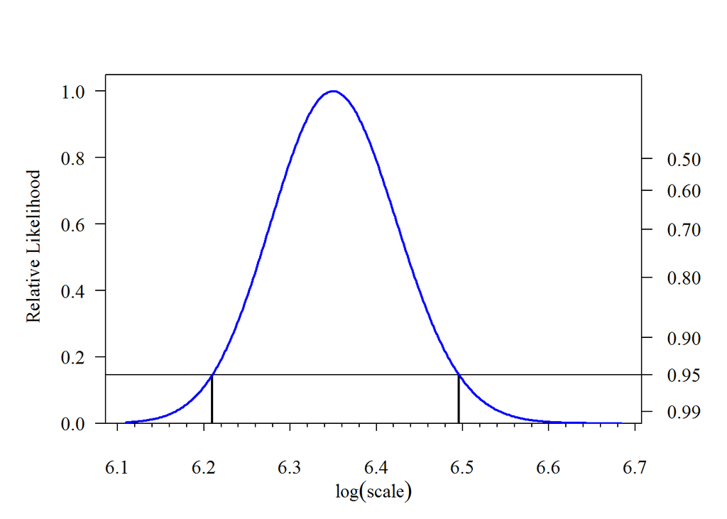

STAT 687 - Chapter 7

## $\S$ 7.3.2 - CI/Significance Test Relationship

STAT 687 - Chapter 7

A significance test (hypothesis test) considers the region of the parameter space that is complement to the region enclosed by the confidence interval

**Confidence Intervals**

- We observe data
- Attempt to fit many distributions
- Find the “most likely” parameters
- Identify the critial values
- Values inside critical values bound our uncertainty on the parameter value

**Significance Test**

- We observe data
- Assume one distribution is correct
- Test a single parameter value
- Identify the critical values
- Values outside critical values indicate the data is inconsitent with our hypothesis

## $\S$ 7.3.2 - CI/Significance Test Relationship

STAT 687 - Chapter 7

The significance test associated with likelihood-based CI’s is known as the **Likelihood Ratio Test**

In the $\alpha$-particle example, our uncertaintly about the value of $\hat{\theta}_{_{MLE}}$ was expressed as all values of $\theta$ for which

$R(\theta|\underline{x})\ge\exp\left[-\chi^2_{(1-\alpha;1)}/2\right]$

In the likelihood ratio test (LRT)

- A single value of $\theta$ is hypothesized, denoted by $\theta_{0}$
- The LRT tests whether the observed data provides sufficient evidence to reject the hypothesized value for $\theta$ or not

## Example 7.7 LRT for the $\alpha$-Particle Data Set

STAT 687 - Chapter 7

Investigators believe that the true value for $\theta=650 \left(\frac{1}{5000}\;\text{seconds}\right)$

The LRT then tests the hypothesis:

$\begin{aligned} H_{0}: \theta &= 650\\ H_{1}: \theta &\ne 650 \end{aligned}$

For the sample with $n=200$ observations, the LRT critical values for $\alpha=.05$ would be

$\begin{aligned} -2\log\left[R(\theta_{0}|\underline{x})\right]&>\chi^2_{(.95,1)}\\ -2\log\left[\frac{\mathcal{L}(\theta_0|\underline{x})}{\mathcal{L}(\hat{\theta}_{_{MLE}}|\underline{x}})\right]&>3.84 \end{aligned}$

## Example 7.7 LRT for the $\alpha$-Particle Data Set

STAT 687 - Chapter 7

For the data set with $n=200$ observations, $\hat{\theta}_{_{MLE}}=572.3$, therefore

The value of the test statistic $2.94$ is less that the critical value of $3.84$

As this value is not in the rejection region, insufficient evidence exists to reject the null hypothesis that $\theta=650$ at the $.05$ significance level.

Meeker notes that the sample with $n=2000$ observations does provide sufficient evidence to reject the null hypothesis that $\theta=650$ at the $.05$ significance level.

## $\S$ 7.3.3 - Normal Approximation CI for $\theta$

STAT 687 - Chapter 7

A two-sided $100(1-\alpha)\%$ CI for $\theta$ based on the normal approximation is expressed as

$\left[\underline{\theta},\overline{\theta}\right]=\hat{\theta}\pm z_{(1-\alpha/2)} \hat{se}_{\hat{\theta}}$

In general, the variance & covariances values for the parameters themselves are computed from the Fisher Information Matrix $\mathscr{I}_{\theta}$

However, when we observe data the “observed information matrix” $\mathcal{I}_{\hat{\theta}}$ is used, where

$\mathscr{I}_{\theta}=-E\left[\frac{\partial^2\mathcal{L}(\underline{\theta}|\underline{x})}{\partial\theta_i\partial\theta_j}\right]=E\left[\mathcal{I}_{\hat{\theta}}\right]$

## Observed Information Matrix

STAT 687 - Chapter 7

The observed information matrix is expressed as

$\mathcal{I}_{\theta}=-\frac{\partial^2\mathcal{l}(\underline{\theta}|\underline{x})}{\partial\theta_i\partial\theta_j}$

For the $\alpha$-particle data set $T\sim EXP(\theta)$, therefore $\mathcal{I}_{\hat{\theta}}$ is a singleton

Recall, the log-likelihood function for the $\alpha$-particle example

$\mathcal{l}(\theta|\underline{t})=\sum_{j=1}^8 d_j \log\left[\exp\left(-\frac{t_{j-1}}{\theta}\right)-\exp\left(-\frac{t_j}{\theta}\right)\right]$

## Observed Information Matrix

STAT 687 - Chapter 7

Taking derivatives gives $\begin{aligned} \frac{\partial\mathcal{l}(\theta)}{\partial\theta}=\frac{d\mathcal{l}(\theta)}{d\theta}&=\sum_{j=1}^8 d_j\frac{\frac{t_{j-1}}{\theta^2}\exp\left(-\frac{t_{j-1}}{\theta}\right)-\frac{t_{j}}{\theta^2}\exp\left(-\frac{t_{j}}{\theta}\right)}{\exp\left(-\frac{t_{j-1}}{\theta}\right)-\exp\left(-\frac{t_{j}}{\theta}\right)}\\\\\\\\ \frac{\partial^2\mathcal{l}(\theta)}{\partial\theta^2}=\frac{d^2\mathcal{l}(\theta)}{d\theta^2}&=\sum_{j=1}^8 d_j\left[\frac{\frac{t_{j-1}}{\theta^2}\exp\left(-\frac{t_{j-1}}{\theta}\right)-\frac{t_{j}}{\theta^2}\exp\left(-\frac{t_{j}}{\theta}\right)}{\exp\left(-\frac{t_{j-1}}{\theta}\right)-\exp\left(-\frac{t_{j}}{\theta}\right)}\right]^2+ \frac{\frac{-2t_{j-1}}{\theta^3}\exp\left(-\frac{t_{j-1}}{\theta}\right)+\frac{t_{j}^4}{\theta^4}\exp\left(-\frac{t_{j}}{\theta}\right)}{\exp\left(-\frac{t_{j-1}}{\theta}\right)-\exp\left(-\frac{t_{j}}{\theta}\right)} \end{aligned}$

The information observed from a data set may be found by substituting any value for $\hat{\theta}$ into $\frac{\partial^2\mathcal{l}(\theta)}{\partial\theta^2}$

Substituting $\hat{\theta}_{_{MLE}}$ maximizes the observed information and is typically used

## $\S$ 7.3.3 - Normal Approximation CI for $\theta$

STAT 687 - Chapter 7

Substituting $\hat{\theta}_{_{MLE}}$ for $\theta$ in $\frac{\partial^2\mathcal{l}(\theta)}{\partial\theta^2}$ gives

$\mathcal{I}_{\hat{\theta}_{_{MLE}}} = 0.000574$

The parameter variance-covariance matrix, denoted as $\Sigma_{\hat{\theta}}$, is found by inverting the observed information matrix

$\Sigma_{\hat{\theta}_{_{MLE}}}=\left[\mathcal{I}_{\hat{\theta}_{_{MLE}}}\right]^{-1}$

For the $\alpha$-particle example the inverse of a single-element matrix is found by simply taking reciprocal, thus

$\Sigma_{\hat{\theta}_{_{MLE}}}=\frac{1}{0.000574}=1742.2$

## Using R to Compute $\mathcal{I}_{\hat{\theta}_{MLE}}$ Numerically

STAT 687 - Chapter 7

Recall, we found $\hat{\theta}_{_{MLE}}$ by defining the likelihood function as

```r
Like7.3<-function(theta,d) {

d1<-d[1];d2<-d[2];d3<-d[3];d4<-d[4];d5<-d[5];d6<-d[6];d7<-d[7];d8<-d[8]

F<-c(rep(NA,1))

F<-log(exp(   -0/theta)-exp( -100/theta))*d1+
   log(exp( -100/theta)-exp( -300/theta))*d2+
   log(exp( -300/theta)-exp( -500/theta))*d3+
   log(exp( -500/theta)-exp( -700/theta))*d4+
   log(exp( -700/theta)-exp(-1000/theta))*d5+
   log(exp(-1000/theta)-exp(-2000/theta))*d6+
   log(exp(-2000/theta)-exp(-4000/theta))*d7+
   log(exp(-4000/theta)-exp( -Inf/theta))*d8

return(-F)      }
```

## Using R to Compute $\mathcal{I}_{\hat{\theta}_{MLE}}$ Numerically

STAT 687 - Chapter 7

We then used the `nlminb` function to compute a value for $\hat{\theta}_{_{MLE}}$ assuming $n=200$

```r
data[2,]
```

```
[1] 41 44 24 32 29 21  9  0
```

```r
nlminb(start = 400, obj = Like7.3, d = data[2,], lower = 100, upper = 800)$par
```

```
[1] 572.27
```

For this problem, we could have also used the `optim` function and arrived at the same solution

```r
optim(par = 400, fn = Like7.3, d = data[2,], lower = 100, upper = 800, method = "L-BFGS-B")$par
```

```
[1] 572.27
```

## Using R to Compute $\mathcal{I}_{\hat{\theta}_{MLE}}$ Numerically

STAT 687 - Chapter 7

Note - `nlminb` is actually a wrapper function for `optim`

However, `optim` includes an argument to return a numerical estimate of the Hessian matrix

```r
optim(par = 400,
      fn = Like7.3,
      d = data[2,],
      lower = 100,
      upper = 800,
      method = "L-BFGS-B", hessian = TRUE)$hessian
```

```
           [,1]
[1,] 0.00057452
```

To compute the the VCV matrix $\Sigma_{\hat{\theta}_{MLE}}$

- Use `solve()` to invert $\mathcal{I}_{\hat{\theta}_{MLE}}$
- Take the reciprocal (only for $1\times 1$ matrices)

Note: the accuracy of this numerical estimate can decrease as the number of unknown parameters increases

## Using R to Compute $\mathcal{I}_{\hat{\theta}_{MLE}}$ Numerically

STAT 687 - Chapter 7

The meekR package makes this really easy

```r
berkson200.ld <- frame.to.ld(berkson200, response.column = 1:2, censor.column = 3, case.weight.column = 4)

berkson200.mlest <- mlest(berkson200.ld, distribution = "Exponential")

print(berkson200.mlest)$mle.table
```

```
                        MLE  Std.Err. 95% Lower 95% Upper
mu                   6.3496  0.072901    6.2067    6.4925
sigma                1.0000  0.000000    1.0000    1.0000
Exponential (mean) 572.2743 41.719540  496.0787  660.1733
```

```r
print(berkson200.mlest)$vcv.matrix
```

```
             mu sigma
mu    0.0053146     0
sigma 0.0000000     0
```

## $\S$ 7.3.3 - Normal Approximation CI for $\theta$

STAT 687 - Chapter 7

In general, the diagonal elements of $\Sigma_{\hat{\theta}_{_{MLE}}}$ represent the variances of the parameters $\widehat{Var}\left[\hat{\theta_1}\right],\widehat{Var}\left[\hat{\theta_2}\right],...$

While the off-diagonal elements represent the covariances $\widehat{Cov}\left[\hat{\theta_i}\hat{\theta_j}\right],\; i\ne j$

For the $\alpha$-particle example $\widehat{Var}\left[\hat{\theta}_{_{MLE}}\right]=1742.2$

and

$\widehat{se}\left[\hat{\theta}_{_{MLE}}\right]=\sqrt{\widehat{Var}\left[\hat{\theta}_{_{MLE}}\right]}=\sqrt{1742.2}=41.72$

## $\S$ 7.3.3 - Normal Approximation CI for $\theta$

STAT 687 - Chapter 7

Returning to Eq 7.6, the $95\%$ confidence bounds for the $\alpha$-particle assuming that

$\frac{\hat{\theta}-\theta}{\hat{se}_{\hat{\theta}}}\sim NOR(0,1)$

can be expressed as

$\left[\underline{\theta}, \overline{\theta}\right]=572.3\pm 1.960\times 41.72=\left[ 490,653 \right]$

where

- $572.3=\hat{\theta}_{_{MLE}}, n=200$
- $1.960=\Phi^{-1}_{_{NOR}}(p=1-0.05/2)$

## $\S$ 7.3.3 - Normal Approximation CI for $\theta$

STAT 687 - Chapter 7

As was discussed in Chapter 2, confidence bands computed using the normal approximation

- Should work well for large samples $n>30$
- May give poor results for small samples

An alternative method to compute $100(1-\alpha)\%$ CI’s assumes that

$\frac{\log(\hat{\theta})-\log(\theta)}{\hat{se}_{\log(\hat{\theta})}}\sim NOR(0,1)$

**For positive quantities** this method produces better results for small samples

## $\S$ 7.3.3 - Normal Approximation CI for $\theta$

STAT 687 - Chapter 7

Using this alternative method the upper and lower confidence limits are expressed as

$\left[\underline{\log(\theta)},\overline{\log(\theta)}\right]=\log(\hat{\theta}) \pm z_{(1-\alpha/2)}\hat{se}_{\log(\hat{\theta})}$

These confidence limits may also be expressed as

$\left[\underline{\theta},\overline{\theta}\right]=\left[\hat{\theta}/w,\hat{\theta}\times w\right]$

where

- $w = \exp(z_{(1-\alpha/2)}\hat{se}_{\hat{\theta}}/\hat{\theta})$
- $\hat{se}_{\log(\hat{\theta})}=\hat{se}_{\hat{\theta}}/\hat{\theta})$

## $\S$ 7.3.3 - Normal Approximation CI for $\theta$

STAT 687 - Chapter 7

$\hat{se}_{\log(\hat{\theta})}$ is found from the delta method where

- $\hat{\theta}\equiv$ the estimator for which we already know the variance
- $\log(\hat{\theta})\equiv$ the estimator for which we want to know the variance

Using the delta method gives

## $\S$ 7.3.3 - Normal Approximation CI for $\theta$

STAT 687 - Chapter 7

Look again at the results produced by the meekR package

```r
print(berkson200.mlest)$mle.table
```

```
                        MLE  Std.Err. 95% Lower 95% Upper
mu                   6.3496  0.072901    6.2067    6.4925
sigma                1.0000  0.000000    1.0000    1.0000
Exponential (mean) 572.2743 41.719540  496.0787  660.1733
```

```r
print(berkson200.mlest)$vcv.matrix
```

```
             mu sigma
mu    0.0053146     0
sigma 0.0000000     0
```

Note that $\Sigma_{\hat{\log(\theta)}_{MLE}}$ is returned, not $\Sigma_{\hat{\theta}_{MLE}}$

## Table 7.3 - Comparison of $\alpha$-Particle ML Results

STAT 687 - Chapter 7

$\begin{array}{lcccc} \hline & n=10220 & n=2000 & n=200 & n=20 \\ \hline \text{ML estimate } \hat{\theta} & 596.3 & 612.8 & 572.3 & 440.2 \\ \text{Standard error } \hat{se}_{\hat{\theta}} & 6.084 & 14.13 & 41.72 & 101.0 \\ \hline \text{Approximate }95\% \text{ CI for } \theta & & & & \\ \hline \text{Based on the likelihood} & [584,608] & [586,641] & [498,662] & [289,713] \\ \text{Based on } Z_{\log(\hat{\theta})}\sim NOR(0,1) & [584,608] & [586,641] & [496,660] & [281,690] \\ \text{Based on } Z_{\hat{\theta}}\sim NOR(0,1) & [584,608] & [585,640] & [490,653] & [242,638] \\ \hline \end{array}$

# Section 7.4|Confidence intervals for functions of $\theta$

## $\S$ 7.4.1 - Confidence Intervals for the Arrival Rate

STAT 687 - Chapter 7

The rate of occurrence for events distributed $EXP(\theta)$ is $\lambda =\frac{1}{\theta}$

Since $\lambda\propto \frac{1}{\theta}$ the following statements can be made

$\begin{aligned} \overline{\theta}&=\underline{\lambda}\\ \underline{\theta}&=\overline{\lambda} \end{aligned}$

And, note that

$\lambda \in \left(\underline{\lambda},\overline{\lambda}\right)\;\;\iff \theta \in \left(\underline{\theta},\overline{\theta}\right)$

## $\S$ 7.4.2 - Confidence intervals for $F(t;\theta)$

STAT 687 - Chapter 7

Like $\lambda,\;F(t|\theta) \propto \frac{1}{\theta}$, therefore

$\left[\underline{F(t|\theta)},\overline{F(t|\theta)}\right]=\left[F(t|\overline{\theta}),F(t\underline{\theta}\right]$

Unlinke what was shown in $\S$ 3.8, these confidence bands are simultaneous since $\theta$ is the only unknown parameter.

And again

$F(t) \in \left(\underline{F(t)},\overline{F(t)\right)\;\;\iff \theta \in \left(\underline{\theta},\overline{\theta}\right)$

## Table 7.3 - Comparison of $\alpha$-Particle ML Results

STAT 687 - Chapter 7

$\begin{array}{lcccc} \hline & n=10220 & n=2000 & n=200 & n=20 \\ \hline \text{ML estimate } \hat{\lambda}\times10^{5} & 168 & 163 & 175 & 227 \\ \text{Standard error } \hat{se}_{\hat{\lambda}\times10^{5}} & 1.7 & 3.8 & 13 & 52 \\ \hline \text{Approximate } 95\% \text{ CI for } \lambda\times10^{5}\ & & & & \\ \hline \text{Based on the likelihood } & [164,171] & [156,171] & [151,201] & [140,346] \\ \text{Based on } Z_{\log(\hat{\lambda})}\sim NOR(0,1) & [164,171] & [156,171] & [152,202] & [145,356] \\ \text{Based on } Z_{\hat{\lambda}}\sim NOR(0,1) & [164,171] & [156,171] & [149,200] & [125,329] \\ \hline \end{array}$

# Section 7.5|Comparison of Confidence Interval Prodcedures

## $\S$ 7.5 - Comparison of CI Procedures

STAT 687 - Chapter 7

Simulation studies have shown that better confidence intervals are produced by

1. Likelihood methods
2. **Bootstrap methods (Chapter 9)**
3. Normal approximation method based on $\log(\hat{\theta})$
4. Normal approximation method based on $\hat{\theta}$

“Better” CI $\equiv$ actual coverage probability closer to the nominal confidence level

# Section 7.6|Likelihood for Exact Failure Times

## $\S$ 7.6.3 - $\hat{\theta}_{_{MLE}}$ based on density approximation

STAT 687 - Chapter 7

As previously discussed, the contribution of “exact” failures to $mathcal{L}$ may be approximated as

$\lim_{\Delta_i\rightarrow 0^+}\left[F(t_i|\theta)-F(t_i-\Delta_i|\theta\right]\approx f(t_i|\theta)\Delta_i$

For right-censored data (no left-censoring or interval-censoring)

- This approximation works well for the exponential distribution
- $\theta$ is estimated by

$\hat{\theta}=\frac{TTT}{r}$

## $\S$ 7.6.3 - $\hat{\theta}_{_{MLE}}$ based on density approximation

STAT 687 - Chapter 7

$\hat{\theta}=\frac{TTT}{r}$

where

- $r \equiv$ the number of failures
- $TTT \equiv$ the total time on test computed as

$TTT=\sum_{i=1}^n t_{i}$

## Calculating Total Time on Test

STAT 687 - Chapter 7

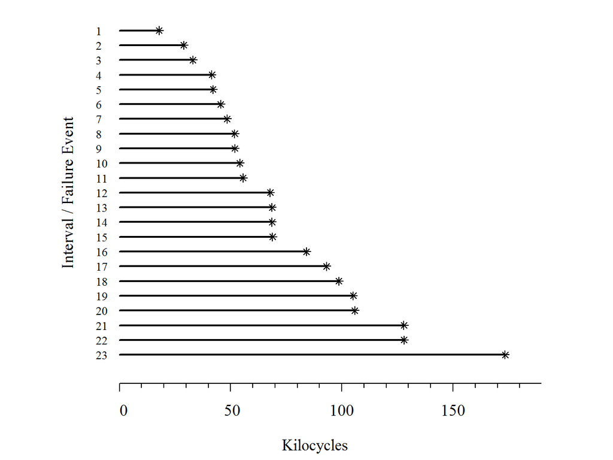

STAT 687 - Chapter 7

STAT 687 - Chapter 7

# Section 7.7|Data analysis with no failures

## $\S$ 7.7 - Data analysis with no failures

STAT 687 - Chapter 7

```r
berkson200.ld <- frame.to.ld(berkson200,
                             response.column =c(1,2),
                             censor.column=3,
                             case.weight.column=4,
                             data.title = "Times Between Alpha Particle Arrival (n=200)",
                             time.units = "1/5000 Seconds")
berkson200.ld
```

```
## Data from  Times Between Alpha Particle Arrival (n=200)
##   Lower Upper     Status Case.weights
## 1   100   100 L-Censored           41
## 2   100   300   Interval           44
## 3   300   500   Interval           24
## 4   500   700   Interval           32
## 5   700  1000   Interval           29
## 6  1000  2000   Interval           21
## 7  2000  4000   Interval            9
## 8  4000  4000 R-Censored            0
```

## $\S$ 7.7 - Data analysis with no failures

STAT 687 - Chapter 7

```r
berkson200.gmle.out <- expon.mle(berkson200.ld)
berkson200.gmle.out
```

```
##
##
##  Times Between Alpha Particle Arrival (n=200)
##
## Response units: 1/5000 Seconds
##
## Exponential Distribution
##
## Maximum likelihood estimation results
##
## Did not converge;
##
## Log likelihood at maximum point: -379.3
##
##  Gradiant of likelihood evaluated at stopping point
## log(scale)
##  2.854e-05
##
##
##  Transformed parameter ML estimates:
## log(scale)
##       6.35
##
##  Transformed parameter ML estimate hessian matrix:
##            log(scale)
## log(scale)      188.2
##
##  Transformed parameter ML estimate variance-covariance matrix
##            log(scale)
## log(scale)   0.005315
## attr(,"error")
## [1] 0
##
##  Transformed parameters  ML estimate correlation matrix
##            log(scale)
## log(scale)          1
## Standard errors for transformed parameter MLEs:
## log(scale)
##     0.0729
##         MLE Std.Err. 95% Lower 95% Upper
## scale 572.3    41.72     490.5       654
##
##  parameter ML estimate variance-covariance matrix
##       scale
## scale  1741
##
##  parameter ML estimate correlation matrix
##       scale
## scale     1
```

## $\S$ 7.7 - Data analysis with no failures

STAT 687 - Chapter 7

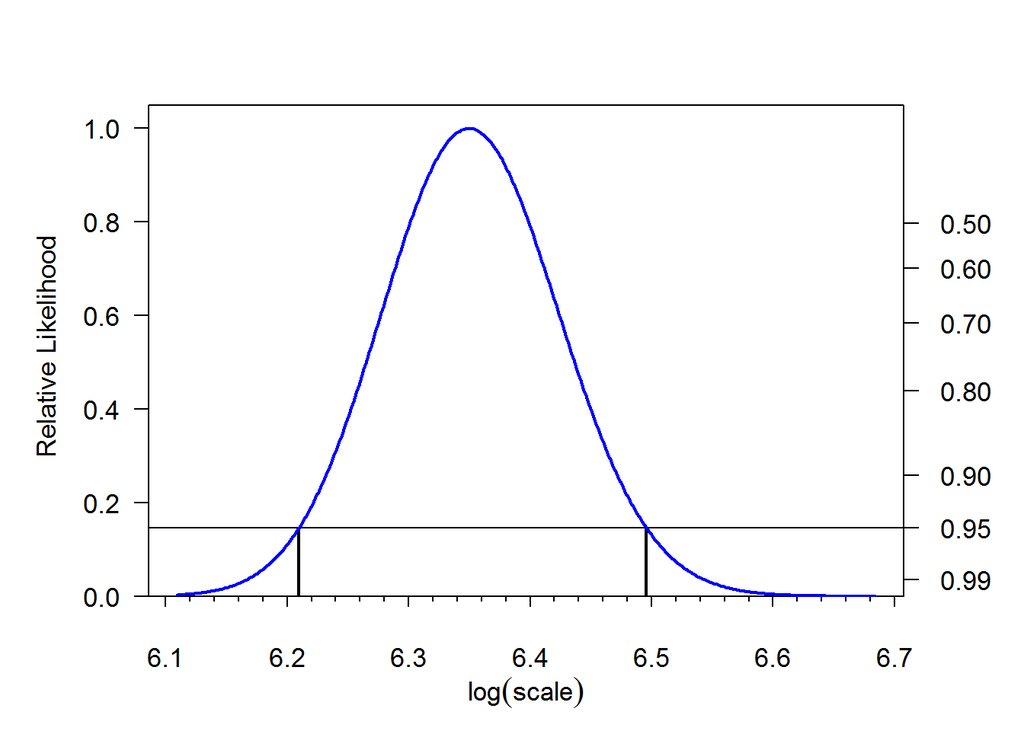

## comptime

[figure not shown]

[output not shown]